# Project_05-classification_7_20-Mahoney

## Project 5 : Classification

## Instructions

### Description

Practice classification on the Titanic dataset.

### Grading

For grading purposes, we will clear all outputs from all your cells and then run them all from the top. Please test your notebook in the same fashion before turning it in.

### Submitting Your Solution

To submit your notebook, first clear all the cells (this won't matter too much this time, but for larger data sets in the future, it will make the file smaller). Then use the File->Download As->Notebook to obtain the notebook file. Finally, submit the notebook file on Canvas.

```python
import pandas as pd
import numpy as np
import sklearn as sk
import matplotlib.pyplot as plt
import seaborn as sns

plt.style.use('ggplot')

%matplotlib inline
%config InlineBackend.figure_format = 'retina'
```

### Introduction

On April 15, 1912, the largest passenger liner ever made collided with an iceberg during her maiden voyage. When the Titanic sank it killed 1502 out of 2224 passengers and crew. This sensational tragedy shocked the international community and led to better safety regulations for ships. One of the reasons that the shipwreck resulted in such loss of life was that there were not enough lifeboats for the passengers and crew. Although there was some element of luck involved in surviving the sinking, some groups of people were more likely to survive than others.

Intro Videos: https://www.youtube.com/watch?v=3lyiZMeTKIo and https://www.youtube.com/watch?v=ItjXTieWKyI

The `titanic_data.csv` file contains data for `887` of the real Titanic passengers. Each row represents one person. The columns describe different attributes about the person including whether they survived (`0=No`), their age, their passenger-class (`1=1st Class, Upper`), gender, and the fare they paid (£s*). For more on the currency: http://www.statisticalconsultants.co.nz/blog/titanic-fare-data.html

We are going to try to see if there are correlations between the feature data provided (find a best subset of features) and passenger survival.

### Problem 1: Load and understand the data (35 points)

#### Your task (some of this is the work you completed for L14 - be sure to copy that work into here as needed)

Conduct some preprocessing steps to explore the following and provide code/answers in the below cells:

1. Load the `titanic_data.csv` file into a pandas dataframe
2. Explore the data provided (e.g., looking at statistics using describe(), value_counts(), histograms, scatter plots of various features, etc.)
3. What are the names of feature columns that appear to be usable for learning?
4. What is the name of the column that appears to represent our target?
5. Formulate a hypothesis about the relationship between given feature data and the target
6. How did Pclass affect passenngers' chances of survival?
7. What is the age distribution of survivors?

```python
# Imports
import numpy as np
import pandas as pd

# Step 1. Load the `titanic_data.csv` file into a pandas dataframe
df = pd.read_csv('titanic_data.csv') # Read in file

display(df.sample(10)) # Display file to get idea for dataset
```

|  | Survived | Pclass | Name | Sex | Age | Siblings/Spouses Aboard | Parents/Children Aboard | Fare |
| --- | --- | --- | --- | --- | --- | --- | --- | --- |
| 225 | 1 | 2 | Mr. William John Mellors | male | 19.0 | 0 | 0 | 10.5000 |
| 406 | 0 | 3 | Mr. Hans Martin Monsen Birkeland | male | 21.0 | 0 | 0 | 7.7750 |
| 489 | 0 | 1 | Mr. Harry Markland Molson | male | 55.0 | 0 | 0 | 30.5000 |
| 748 | 0 | 3 | Mr. Johannes Joseph Vande Velde | male | 33.0 | 0 | 0 | 9.5000 |
| 243 | 0 | 3 | Mr. Sleiman Attalah | male | 30.0 | 0 | 0 | 7.2250 |
| 661 | 1 | 3 | Mr. Eino William Lindqvist | male | 20.0 | 1 | 0 | 7.9250 |
| 115 | 0 | 3 | Mr. Patrick Connors | male | 70.5 | 0 | 0 | 7.7500 |
| 809 | 0 | 3 | Miss. Ebba Iris Alfrida Andersson | female | 6.0 | 4 | 2 | 31.2750 |
| 876 | 1 | 2 | Mrs. William (Imanita Parrish Hall) Shelley | female | 25.0 | 0 | 1 | 26.0000 |
| 565 | 0 | 3 | Mr. Tannous Doharr | male | 28.0 | 0 | 0 | 7.2292 |

```python
# Step 2. Explore the data provided (e.g., looking at statistics using describe(), value_counts(), histograms, scatter plots of various features, etc.)

print(df.describe())
print(df.value_counts())

# Finding Intresting mins and maxs
print(df[df.Age == df.Age.max()])

print(df[df.Age == df.Age.min()])

# Using Groupby function

df.groupby('Fare')

# Scatter plots
#display(df.plot.scatter)
df.plot(x='Fare', y='Survived')
```

```
         Survived      Pclass         Age  Siblings/Spouses Aboard  \
count  887.000000  887.000000  887.000000               887.000000
mean     0.385569    2.305524   29.471443                 0.525366
std      0.487004    0.836662   14.121908                 1.104669
min      0.000000    1.000000    0.420000                 0.000000
25%      0.000000    2.000000   20.250000                 0.000000
50%      0.000000    3.000000   28.000000                 0.000000
75%      1.000000    3.000000   38.000000                 1.000000
max      1.000000    3.000000   80.000000                 8.000000

       Parents/Children Aboard       Fare
count               887.000000  887.00000
mean                  0.383315   32.30542
std                   0.807466   49.78204
min                   0.000000    0.00000
25%                   0.000000    7.92500
50%                   0.000000   14.45420
75%                   0.000000   31.13750
max                   6.000000  512.32920
Survived  Pclass  Name                                      Sex     Age   Siblings/Spouses Aboard  Parents/Children Aboard  Fare
0         1       Capt. Edward Gifford Crosby               male    70.0  1                        1                        71.0000     1
1         1       Miss. Sara Rebecca Compton                female  39.0  1                        1                        83.1583     1
                  Miss. Madeleine Newell                    female  31.0  1                        0                        113.2750    1
                  Miss. Margaret Bechstein Hays             female  24.0  0                        0                        83.1583     1
                  Miss. Margaret Edith Graham               female  19.0  0                        0                        30.0000     1
                                                                                                                                       ..
0         3       Mr. Erik Johansson                        male    22.0  0                        0                        7.7958      1
                  Mr. Ernest Charles Cann                   male    21.0  0                        0                        8.0500      1
                  Mr. Ernest James Crease                   male    19.0  0                        0                        8.1583      1
                  Mr. Ernest Portage Tomlin                 male    30.5  0                        0                        8.0500      1
1         3       Mrs. Thomas Henry (Mary E Finck) Davison  female  34.0  1                        0                        16.1000     1
Length: 887, dtype: int64
     Survived  Pclass                                 Name   Sex   Age  \
627         1       1  Mr. Algernon Henry Wilson Barkworth  male  80.0

     Siblings/Spouses Aboard  Parents/Children Aboard  Fare
627                        0                        0  30.0
     Survived  Pclass                            Name   Sex   Age  \
799         1       3  Master. Assad Alexander Thomas  male  0.42

     Siblings/Spouses Aboard  Parents/Children Aboard    Fare
799                        0                        1  8.5167
```

[figure not shown]

**Edit this cell to provide answers to the following steps:**

Step 3. What are the names of feature columns that appear to be usable for learning?

Columns used to predict survival: Age, Pclass, Sex, Fare, Parents/children Aboard, Siblings/Spouses Aboard (although sex is not numerical)

Step 4. What is the name of the column that appears to represent our target?

Survived

Step 5. Formulate a hypothesis about the relationship between given feature data and the target

Hypothesis: Lower passenger class number (class one being lowest) will have a positive correlation with survival.

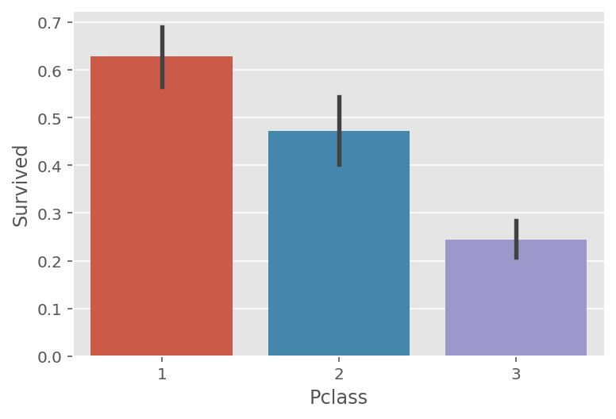

```python
#Step 6. How did Pclass affect passenngers' chances of survival?
#Show your work with a bar plot, dataframe selection, or visual of your choice.

import seaborn as sns

sns.barplot(x='Pclass', y='Survived', data=df
           )
```

Lower passenger class (class 1) positively affecetd passenger survival rates. This is intuitive as first class passengers were documeneted to have a higher survival rate.

```python
#Step 7. What is the age distribution of survivors?
#Show your work with a dataframe operation and/or histogram plot.

df.plot(x='Survived', y='Age', kind='hist')
```

[figure not shown]

### Problem 2: transform the data (10 points)

The `Sex` column is categorical, meaning its data are separable into groups, but not numerical. To be able to work with this data, we need numbers, so you task is to transform the `Sex` column into numerical data with pandas' `get_dummies` feature and remove the original categorical `Sex` column.

```python
new_df = pd.get_dummies(df, columns=['Sex'])

display(new_df)
```

|  | Survived | Pclass | Name | Age | Siblings/Spouses Aboard | Parents/Children Aboard | Fare | Sex_female | Sex_male |
| --- | --- | --- | --- | --- | --- | --- | --- | --- | --- |
| 0 | 0 | 3 | Mr. Owen Harris Braund | 22.0 | 1 | 0 | 7.2500 | 0 | 1 |
| 1 | 1 | 1 | Mrs. John Bradley (Florence Briggs Thayer) Cum... | 38.0 | 1 | 0 | 71.2833 | 1 | 0 |
| 2 | 1 | 3 | Miss. Laina Heikkinen | 26.0 | 0 | 0 | 7.9250 | 1 | 0 |
| 3 | 1 | 1 | Mrs. Jacques Heath (Lily May Peel) Futrelle | 35.0 | 1 | 0 | 53.1000 | 1 | 0 |
| 4 | 0 | 3 | Mr. William Henry Allen | 35.0 | 0 | 0 | 8.0500 | 0 | 1 |
| ... | ... | ... | ... | ... | ... | ... | ... | ... | ... |
| 882 | 0 | 2 | Rev. Juozas Montvila | 27.0 | 0 | 0 | 13.0000 | 0 | 1 |
| 883 | 1 | 1 | Miss. Margaret Edith Graham | 19.0 | 0 | 0 | 30.0000 | 1 | 0 |
| 884 | 0 | 3 | Miss. Catherine Helen Johnston | 7.0 | 1 | 2 | 23.4500 | 1 | 0 |
| 885 | 1 | 1 | Mr. Karl Howell Behr | 26.0 | 0 | 0 | 30.0000 | 0 | 1 |
| 886 | 0 | 3 | Mr. Patrick Dooley | 32.0 | 0 | 0 | 7.7500 | 0 | 1 |

887 rows × 9 columns

### Problem 3: Classification (30 points)

Now that the data is transformed, we want to run various classification experiments on it. The first is `K Nearest Neighbors`, which you will conduct by:

1. Define input and target data by creating lists of dataframe columns (e.g., inputs = ['Pclass', etc.)
2. Split the data into training and testing sets with `train_test_split()`
3. Create a `KNeighborsClassifier` using `5` neighbors at first (you can experiment with this parameter)
4. Train your model by passing the training dataset to `fit()`
5. Calculate predicted target values(y_hat) by passing the testing dataset to `predict()`
6. Print the accuracy of the model with `score()`

** Note: If you get a python warning as you use the Y, trainY, or testY vector in some of the function calls about "DataConversionWarning: A column-vector y was passed when a 1d array was expected. Please change the shape of y to (n_samples, )", you can look up how to use trainY.values.ravel() or trainY.values.flatten() or another function, etc.

```python
import numpy as np
import pandas as pd
import matplotlib.pyplot as plt
import sklearn as sk

from scipy.stats import norm
from pandas import Series, DataFrame
from sklearn.model_selection import train_test_split
from matplotlib.colors import ListedColormap

plt.style.use('ggplot')


%matplotlib inline
%config InlineBackend.figure_format = 'svg'
```

```python
import sklearn as sk
from sklearn.model_selection import train_test_split


# Step 1:
inputs = ['Pclass', 'Age', 'Fare', 'Sex_female', 'Sex_male']
target = ['Survived']


# Step 2
X = new_df[inputs]
Y = new_df['Survived']

Xtrain, Xtest, Ytrain, Ytest = sk.model_selection.train_test_split(X, Y, test_size=0.25, random_state=16)



# Step 3
from sklearn.neighbors import KNeighborsClassifier

k = 5

model_KN = KNeighborsClassifier(k)


# Step 4
model_KN.fit(Xtrain, Ytrain)


# Step 5
prediction = model_KN.predict(Xtest)


# Step 6
print("Accuracy:", model_KN.score(Xtest, Ytest)*100)
```

```
Accuracy: 68.91891891891892
```

### Problem 4: Cross validation, classification report (15 points)

- Using the concepts from the 17-model_selection slides and the [`cross_val_score`](http://scikit-learn.org/stable/modules/generated/sklearn.model_selection.cross_val_score.html) function from scikit-learn, estimate the f-score ([`f1-score`](http://scikit-learn.org/stable/modules/generated/sklearn.metrics.f1_score.html#sklearn.metrics.f1_score) (you can use however many folds you wish). To get `cross_val_score` to use `f1-score` rather than the default accuracy measure, you will need to set the `scoring` parameter and use a scorer object created via [`make_scorer`](http://scikit-learn.org/stable/modules/generated/sklearn.metrics.make_scorer.html#sklearn.metrics.make_scorer). Since this has a few parts to it, let me just give you that parameter: `scorerVar = make_scorer(f1_score, pos_label=1)`
- Using the concepts from the end of the 14-classification slides, output a confusion matrix.
- Also, output a classification report [`classification_report`](http://scikit-learn.org/stable/modules/generated/sklearn.metrics.classification_report.html) from sklearn.metrics showing more of the metrics: precision, recall, f1-score for both of our classes.

```python
import sklearn
from sklearn import metrics
from sklearn.metrics import confusion_matrix, f1_score, classification_report, make_scorer
from sklearn import model_selection

# Estimate f score
f_1 = metrics.f1_score(Ytest, prediction, average = None)

scorerVar = make_scorer(f1_score, pos_label=1)
print("f_1 Estimate:", f_1)

# Cross-Val score
cross_val = sklearn.model_selection.cross_val_score(model_KN, X, y=Y, cv = 10)
print('Cross Val Score:', cross_val)

# Ouput confusion matrix
print('Confusion Matrix:', confusion_matrix(Ytest, prediction))

# Output Classification Report
print('Classification Report:', classification_report(Ytest, prediction))
```

```
f_1 Estimate: [0.76124567 0.55483871]
Cross Val Score: [0.71910112 0.61797753 0.66292135 0.68539326 0.69662921 0.73033708
 0.76404494 0.75       0.65909091 0.78409091]
Confusion Matrix: [[110  26]
 [ 43  43]]
Classification Report:               precision    recall  f1-score   support

           0       0.72      0.81      0.76       136
           1       0.62      0.50      0.55        86

    accuracy                           0.69       222
   macro avg       0.67      0.65      0.66       222
weighted avg       0.68      0.69      0.68       222
```

### Problem 5: Support Vector Machines (15 points)

Now, repeat the above experiment using the using a Support Vector classifier [`SVC`](http://scikit-learn.org/stable/modules/generated/sklearn.svm.SVC.html) with default parameters (RBF kernel) model in scikit-learn, and output:

- The fit accuracy (using the `score` method of the model)
- The f-score (using the [`cross_val_score`](http://scikit-learn.org/stable/modules/generated/sklearn.model_selection.cross_val_score.html) function)
- The confusion matrix
- The precision, recall, and f-measure for the 1 class (you can just print the results of the [`classification_report`](http://scikit-learn.org/stable/modules/generated/sklearn.metrics.classification_report.html) function from sklearn.metrics)

```python
# set up
import numpy as np
import pandas as pd
import matplotlib.pyplot as plt
import sklearn as sk
from scipy.stats import norm
from pandas import Series, DataFrame
from matplotlib.colors import ListedColormap
plt.style.use('ggplot')

%matplotlib inline
%config InlineBackend.figure_format = 'retina'
from sklearn.svm import SVC
from sklearn.model_selection import cross_val_score

# Step 1: df
inputs = ['Pclass', 'Age', 'Fare', 'Sex_female', 'Sex_male']
target = ['Survived']


# Step 2
X = new_df[inputs]
Y = new_df['Survived']

Xtrain, Xtest, Ytrain, Ytest = sk.model_selection.train_test_split(X, Y, test_size=0.25, random_state=16)


# STep 3 create model object
from sklearn import svm
model_svm = svm.SVC(kernel='linear', C=10)


# Step 4 train our model
model_svm.fit(Xtrain, Ytrain)


# Step 5 Prediciton
prediction_svm = model_svm.predict(Xtest)


# Step 6 Accuracy
print("Accuracy:", model_svm.score(Xtest, Ytest)*100)



#setup to get f-score and cv
f_1 = metrics.f1_score(Ytest, prediction_svm, average = None)

scorerVar = make_scorer(f1_score, pos_label=1)
print("f_1 Estimate:", f_1)

# Cross-Val score
cross_val = sklearn.model_selection.cross_val_score(model_svm, X, y=Y, cv = 10)
print('Cross Val Score:', cross_val)

# Ouput confusion matrix
print('Confusion Matrix:', confusion_matrix(Ytest, prediction_svm))

# Output Classification Report
print('Classification Report:', classification_report(Ytest, prediction_svm))
```

```
Accuracy: 80.63063063063063
f_1 Estimate: [0.84476534 0.74251497]
Cross Val Score: [0.82022472 0.78651685 0.76404494 0.85393258 0.78651685 0.75280899
 0.7752809  0.75       0.80681818 0.76136364]
Confusion Matrix: [[117  19]
 [ 24  62]]
Classification Report:               precision    recall  f1-score   support

           0       0.83      0.86      0.84       136
           1       0.77      0.72      0.74        86

    accuracy                           0.81       222
   macro avg       0.80      0.79      0.79       222
weighted avg       0.80      0.81      0.81       222
```

### Problem 6: Logistic Regression (15 points)

Now, repeat the above experiment using the [`LogisticRegression`](http://scikit-learn.org/stable/modules/generated/sklearn.linear_model.LogisticRegression.html) model in scikit-learn, and output:

- The fit accuracy (using the `score` method of the model)
- The f-score (using the [`cross_val_score`](http://scikit-learn.org/stable/modules/generated/sklearn.model_selection.cross_val_score.html) function)
- The confusion matrix
- The precision, recall, and f-measure for the 1 class (you can just print the results of the [`classification_report`](http://scikit-learn.org/stable/modules/generated/sklearn.metrics.classification_report.html) function from sklearn.metrics)

```python
# set up
import numpy as np
import pandas as pd
import matplotlib.pyplot as plt
import sklearn as sk
from scipy.stats import norm
from pandas import Series, DataFrame
from matplotlib.colors import ListedColormap
plt.style.use('ggplot')

%matplotlib inline
%config InlineBackend.figure_format = 'retina'
from sklearn.svm import SVC
from sklearn.model_selection import cross_val_score

# Step 1: df
inputs = ['Pclass', 'Age', 'Fare', 'Sex_female', 'Sex_male']
target = ['Survived']

# Step 2
X = new_df[inputs]
Y = new_df['Survived']

Xtrain, Xtest, Ytrain, Ytest = sk.model_selection.train_test_split(X, Y, test_size=0.25, random_state=16)


# STep 3 create model object
import sklearn as sk
from sklearn.linear_model import LogisticRegression
model_logreg = sk.linear_model.LogisticRegression()


# Step 4 train our model
model_logreg.fit(Xtrain, Ytrain)


# Step 5 Prediciton
prediction_logreg = model_logreg.predict(Xtest)


# Step 6 Accuracy
print("Accuracy:", model_logreg.score(Xtest, Ytest)*100)



#setup to get f-score
f_1 = metrics.f1_score(Ytest, prediction_logreg, average = None)

scorerVar = make_scorer(f1_score, pos_label=1)
print("f_1 Estimate:", f_1)

# Cross-Val score
cross_val = sklearn.model_selection.cross_val_score(model_logreg, X, y=Y, cv = 10)
print('Cross Val Score:', cross_val)

# Ouput confusion matrix
print('Confusion Matrix:', confusion_matrix(Ytest, prediction_logreg))

# Output Classification Report
print('Classification Report:', classification_report(Ytest, prediction_logreg))
```

```
Accuracy: 82.88288288288288
f_1 Estimate: [0.86231884 0.77380952]
Cross Val Score: [0.79775281 0.79775281 0.75280899 0.84269663 0.78651685 0.76404494
 0.80898876 0.78409091 0.80681818 0.79545455]
Confusion Matrix: [[119  17]
 [ 21  65]]
Classification Report:               precision    recall  f1-score   support

           0       0.85      0.88      0.86       136
           1       0.79      0.76      0.77        86

    accuracy                           0.83       222
   macro avg       0.82      0.82      0.82       222
weighted avg       0.83      0.83      0.83       222
```

### Problem 7: Comparision and Discussion (5 points)

Edit this cell to provide a brief discussion (3-5 sentances at most):

1. What was the model/algorithm that performed best for you?  
   Logistic Regression based on accuracy, f1 score and precision
2. What feaures and parameters were used to achieve that performance?  
   I looked at 'Pclass', 'Age', 'Fare', 'Sex_female', 'Sex_male'.
3. What insights did you gain from your experimentation about the predictive power of this dataset and did it match your original hypothesis about the relationship between given feature data and the target?  
   I confirmed that my hypothesis was correct in that first class passengers had a much higher chance of survval than those in lower classes.

### Questionnaire

1) How long did you spend on this assignment?  
~8 Hours  
2) What did you like about it? What did you not like about it?  
I liked being able to compare different types of models, I did not like the amount of time this assignment took.  
3) Did you find any errors or is there anything you would like changed?  
If this could be changed to be even one problem shorter, it would be better